# Funções do R para estatística descritiva

Mauro Campos

25 de abril de 2023

**Referências** para leitura deste material:

- P. Morettin & W. Bussab. Estatística Básica. 6a ed. São Paulo: Saraiva, 2010.
- M. Campos. Introdução ao R. Vitória, 2018. Disponível em: https://maurocmcampos.github.io/ec/html/intror.html.
- Learn R programming: simply easy learning. Disponível em: https://www.tutorialspoint.com/r/index.htm.

# 1 Lendo um conjunto de dados de um arquivo externo

Nas primeiras quatro seções deste material discutiremos exemplos que utilizam o seguinte conjunto de dados, extraído do Capítulo 2 da referência Morettin & Bussab (2010). A função `read.table()` pode ser usada para ler um arquivo externo do tipo .txt. A função `read.csv()` faz o mesmo para arquivos do tipo .csv (comma-separated values file).

```r
df0 <- read.table(file="tab.txt",header=TRUE,stringsAsFactors=FALSE)
df0
##     N estado_civil grau_instrucao n_filhos salario idade reg_procedencia
## 1   1     solteiro    fundamental       NA    4.00    26        interior
## 2   2       casado    fundamental        1    4.56    32         capital
## 3   3       casado    fundamental        2    5.25    36         capital
## 4   4     solteiro          medio       NA    5.73    20           outra
## 5   5     solteiro    fundamental       NA    6.26    40           outra
## 6   6       casado    fundamental        0    6.66    28        interior
## 7   7     solteiro    fundamental       NA    6.86    41        interior
## 8   8     solteiro    fundamental       NA    7.39    43         capital
## 9   9       casado          medio        1    7.59    34         capital
## 10 10     solteiro          medio       NA    7.44    23           outra
## 11 11       casado          medio        2    8.12    33        interior
## 12 12     solteiro    fundamental       NA    8.46    27         capital
## 13 13     solteiro          medio       NA    8.74    37           outra
## 14 14       casado    fundamental        3    8.95    44           outra
## 15 15       casado          medio        0    9.13    30        interior
## 16 16     solteiro          medio       NA    9.35    38           outra
## 17 17       casado          medio        1    9.77    31         capital
## 18 18       casado    fundamental        2    9.80    39           outra
## 19 19     solteiro       superior       NA   10.53    25        interior
## 20 20     solteiro          medio       NA   10.76    37        interior
## 21 21       casado          medio        1   11.06    30           outra
## 22 22     solteiro          medio       NA   11.59    34         capital
## 23 23     solteiro    fundamental       NA   12.00    41           outra
## 24 24       casado       superior        0   12.79    26           outra
## 25 25       casado          medio        2   13.23    32        interior
## 26 26       casado          medio        2   13.60    35           outra
## 27 27     solteiro    fundamental       NA   13.85    46           outra
## 28 28       casado          medio        0   14.69    29        interior
## 29 29       casado          medio        5   14.71    40        interior
## 30 30       casado          medio        2   15.99    35         capital
## 31 31     solteiro       superior       NA   16.22    31           outra
## 32 32       casado          medio        1   16.61    36        interior
## 33 33       casado       superior        3   17.26    43         capital
## 34 34     solteiro       superior       NA   18.75    33         capital
## 35 35       casado          medio        2   19.40    48         capital
## 36 36       casado       superior        3   23.30    42        interior
```

# 2 Entendendo a estrutura do conjunto de dados

Uma vez que o conjunto de dados foi lido e armazenada em um objeto, é necessário conhecer sua estrutura. Isto significa, saber quantas observações existem, quantas e quais são as variáveis envolvidas, seus tipos e valores. Esta tarefa pode ser feita com a função `str()`. A função `head()` mostra as 6 primeiras linhas de um conjunto de dados e a função `tail()` mostra as 6 últimas linhas. A função `class()` retorna a estrutura de dados que foi utilizada para armazenar as variáveis do conjunto de dados em questão. No caso a estrutura utilizada foi um data frame.

```r
str(df0)
## 'data.frame':    36 obs. of  7 variables:
##  $ N              : int  1 2 3 4 5 6 7 8 9 10 ...
##  $ estado_civil   : chr  "solteiro" "casado" "casado" "solteiro" ...
##  $ grau_instrucao : chr  "fundamental" "fundamental" "fundamental" "medio" ...
##  $ n_filhos       : int  NA 1 2 NA NA 0 NA NA 1 NA ...
##  $ salario        : num  4 4.56 5.25 5.73 6.26 6.66 6.86 7.39 7.59 7.44 ...
##  $ idade          : int  26 32 36 20 40 28 41 43 34 23 ...
##  $ reg_procedencia: chr  "interior" "capital" "capital" "outra" ...
head(df0)
##   N estado_civil grau_instrucao n_filhos salario idade reg_procedencia
## 1 1     solteiro    fundamental       NA    4.00    26        interior
## 2 2       casado    fundamental        1    4.56    32         capital
## 3 3       casado    fundamental        2    5.25    36         capital
## 4 4     solteiro          medio       NA    5.73    20           outra
## 5 5     solteiro    fundamental       NA    6.26    40           outra
## 6 6       casado    fundamental        0    6.66    28        interior
tail(df0)
##     N estado_civil grau_instrucao n_filhos salario idade reg_procedencia
## 31 31     solteiro       superior       NA   16.22    31           outra
## 32 32       casado          medio        1   16.61    36        interior
## 33 33       casado       superior        3   17.26    43         capital
## 34 34     solteiro       superior       NA   18.75    33         capital
## 35 35       casado          medio        2   19.40    48         capital
## 36 36       casado       superior        3   23.30    42        interior
class(df0)
## [1] "data.frame"
```

# 3 Funções para síntese numérica de um conjunto de dados

A função `summary()` proporciona uma síntese numérica rápida e simplificada para todas as variáveis de um conjunto de dados.

```r
summary(df0)
##        N         estado_civil       grau_instrucao        n_filhos
##  Min.   : 1.00   Length:36          Length:36          Min.   :0.00
##  1st Qu.: 9.75   Class :character   Class :character   1st Qu.:1.00
##  Median :18.50   Mode  :character   Mode  :character   Median :2.00
##  Mean   :18.50                                         Mean   :1.65
##  3rd Qu.:27.25                                         3rd Qu.:2.00
##  Max.   :36.00                                         Max.   :5.00
##                                                        NA's   :16
##     salario           idade       reg_procedencia
##  Min.   : 4.000   Min.   :20.00   Length:36
##  1st Qu.: 7.553   1st Qu.:30.00   Class :character
##  Median :10.165   Median :34.50   Mode  :character
##  Mean   :11.122   Mean   :34.58
##  3rd Qu.:14.060   3rd Qu.:40.00
##  Max.   :23.300   Max.   :48.00
##
```

Note que a função `summary` não proporcionou uma síntese adequada para as variáveis categóricas: **estado civil**, **grau de instrução** e **região de procedência**. Isso ocorreu porque estas variáveis estão armazenadas em `df0` como vetores de caracteres (veja a estrutura de `df0` para confirmar esta observação). Ainda que em situações simples seja possível realizar análises de variáveis categóricas armazenadas como vetores de caracteres, é mais adequado utilizar a estrutura `factor()` (fator em Português) para armazenar tais variáveis. O script que segue realiza esta conversão de vetores de caracteres para fatores para as variáveis em questão.

```r
#
# Vamos preservar df0 apenas para comparação
#
df <- df0
niveis.ec <- c("solteiro","casado")
niveis.gi <- c("fundamental","medio","superior")
niveis.rp <- c("capital","interior","outra")
df$estado_civil <- factor(df$estado_civil,levels=niveis.ec)
df$grau_instrucao <- factor(df$grau_instrucao,levels=niveis.gi,ordered=TRUE)
df$reg_procedencia <- factor(df$reg_procedencia,levels=niveis.rp)
#
# Variáveis como fatores em df
#
df$estado_civil
##  [1] solteiro casado   casado   solteiro solteiro casado   solteiro solteiro
##  [9] casado   solteiro casado   solteiro solteiro casado   casado   solteiro
## [17] casado   casado   solteiro solteiro casado   solteiro solteiro casado
## [25] casado   casado   solteiro casado   casado   casado   solteiro casado
## [33] casado   solteiro casado   casado
## Levels: solteiro casado
df$grau_instrucao
##  [1] fundamental fundamental fundamental medio       fundamental fundamental
##  [7] fundamental fundamental medio       medio       medio       fundamental
## [13] medio       fundamental medio       medio       medio       fundamental
## [19] superior    medio       medio       medio       fundamental superior
## [25] medio       medio       fundamental medio       medio       medio
## [31] superior    medio       superior    superior    medio       superior
## Levels: fundamental < medio < superior
df$reg_procedencia
##  [1] interior capital  capital  outra    outra    interior interior capital
##  [9] capital  outra    interior capital  outra    outra    interior outra
## [17] capital  outra    interior interior outra    capital  outra    outra
## [25] interior outra    outra    interior interior capital  outra    interior
## [33] capital  capital  capital  interior
## Levels: capital interior outra
```

Compare agora com as estruturas de `df` e `df0`.

```r
str(df)
## 'data.frame':    36 obs. of  7 variables:
##  $ N              : int  1 2 3 4 5 6 7 8 9 10 ...
##  $ estado_civil   : Factor w/ 2 levels "solteiro","casado": 1 2 2 1 1 2 1 1 2 1 ...
##  $ grau_instrucao : Ord.factor w/ 3 levels "fundamental"<..: 1 1 1 2 1 1 1 1 2 2 ...
##  $ n_filhos       : int  NA 1 2 NA NA 0 NA NA 1 NA ...
##  $ salario        : num  4 4.56 5.25 5.73 6.26 6.66 6.86 7.39 7.59 7.44 ...
##  $ idade          : int  26 32 36 20 40 28 41 43 34 23 ...
##  $ reg_procedencia: Factor w/ 3 levels "capital","interior",..: 2 1 1 3 3 2 2 1 1 3 ...
str(df0)
## 'data.frame':    36 obs. of  7 variables:
##  $ N              : int  1 2 3 4 5 6 7 8 9 10 ...
##  $ estado_civil   : chr  "solteiro" "casado" "casado" "solteiro" ...
##  $ grau_instrucao : chr  "fundamental" "fundamental" "fundamental" "medio" ...
##  $ n_filhos       : int  NA 1 2 NA NA 0 NA NA 1 NA ...
##  $ salario        : num  4 4.56 5.25 5.73 6.26 6.66 6.86 7.39 7.59 7.44 ...
##  $ idade          : int  26 32 36 20 40 28 41 43 34 23 ...
##  $ reg_procedencia: chr  "interior" "capital" "capital" "outra" ...
```

Compare agora com o `summary(df)` com o `summary(df0)`.

```r
summary(df)
##        N           estado_civil     grau_instrucao    n_filhos
##  Min.   : 1.00   solteiro:16    fundamental:12     Min.   :0.00
##  1st Qu.: 9.75   casado  :20    medio      :18     1st Qu.:1.00
##  Median :18.50                  superior   : 6     Median :2.00
##  Mean   :18.50                                     Mean   :1.65
##  3rd Qu.:27.25                                     3rd Qu.:2.00
##  Max.   :36.00                                     Max.   :5.00
##                                                    NA's   :16
##     salario           idade       reg_procedencia
##  Min.   : 4.000   Min.   :20.00   capital :11
##  1st Qu.: 7.553   1st Qu.:30.00   interior:12
##  Median :10.165   Median :34.50   outra   :13
##  Mean   :11.122   Mean   :34.58
##  3rd Qu.:14.060   3rd Qu.:40.00
##  Max.   :23.300   Max.   :48.00
##
summary(df0)
##        N         estado_civil       grau_instrucao        n_filhos
##  Min.   : 1.00   Length:36          Length:36          Min.   :0.00
##  1st Qu.: 9.75   Class :character   Class :character   1st Qu.:1.00
##  Median :18.50   Mode  :character   Mode  :character   Median :2.00
##  Mean   :18.50                                         Mean   :1.65
##  3rd Qu.:27.25                                         3rd Qu.:2.00
##  Max.   :36.00                                         Max.   :5.00
##                                                        NA's   :16
##     salario           idade       reg_procedencia
##  Min.   : 4.000   Min.   :20.00   Length:36
##  1st Qu.: 7.553   1st Qu.:30.00   Class :character
##  Median :10.165   Median :34.50   Mode  :character
##  Mean   :11.122   Mean   :34.58
##  3rd Qu.:14.060   3rd Qu.:40.00
##  Max.   :23.300   Max.   :48.00
##
```

## 3.1 Variável numérica contínua

Uma síntese detalhada pode ser obtida com as seguintes funções. Como exemplo de síntese numérica de uma variável quantitativa contínua, considere a variável **salário**.

```r
df$salario
##  [1]  4.00  4.56  5.25  5.73  6.26  6.66  6.86  7.39  7.59  7.44  8.12  8.46
## [13]  8.74  8.95  9.13  9.35  9.77  9.80 10.53 10.76 11.06 11.59 12.00 12.79
## [25] 13.23 13.60 13.85 14.69 14.71 15.99 16.22 16.61 17.26 18.75 19.40 23.30
summary(df$salario)
##    Min. 1st Qu.  Median    Mean 3rd Qu.    Max.
##   4.000   7.553  10.165  11.122  14.060  23.300
mean(df$salario)
## [1] 11.12222
median(df$salario)
## [1] 10.165
quantile(df$salario,c(0.25,0.50,0.75))
##     25%     50%     75%
##  7.5525 10.1650 14.0600
IQR(df$salario) # Retorna a distância interquartil = Q3 - Q1.
## [1] 6.5075
min(df$salario)
## [1] 4
max(df$salario)
## [1] 23.3
var(df$salario)
## [1] 21.04477
sd(df$salario)
## [1] 4.587458
```

## 3.2 Variável numérica discreta

Como exemplo de síntese numérica de uma variável quantitativa discreta, considere a variável **número de filhos**.

```r
df$n_filhos
##  [1] NA  1  2 NA NA  0 NA NA  1 NA  2 NA NA  3  0 NA  1  2 NA NA  1 NA NA  0  2
## [26]  2 NA  0  5  2 NA  1  3 NA  2  3
summary(df$n_filhos)
##    Min. 1st Qu.  Median    Mean 3rd Qu.    Max.    NA's
##    0.00    1.00    2.00    1.65    2.00    5.00      16
mean(df$n_filhos)
## [1] NA
#
# Note que a função mean() não retornou a média da variável número de filhos.
# Isto aconteceu porque na variável em questão existem valores não disponíveis
# (valores NA - Not Available values). Neste caso, é necessário informar ao R
# que estes valores não disponíveis devem ser removidos e que o cálculo deve ser
# realizado com as observações restantes. Isto é feito definindo o argumento
# na.rm como TRUE. Observação análoga vale para outras estatísticas.
#
mean(df$n_filhos,na.rm=TRUE)
## [1] 1.65
median(df$n_filhos,na.rm=TRUE)
## [1] 2
quantile(df$n_filhos,c(0.25,0.50,0.75),na.rm=TRUE)
## 25% 50% 75%
##   1   2   2
IQR(df$n_filhos,na.rm=TRUE)
## [1] 1
min(df$n_filhos,na.rm=TRUE)
## [1] 0
max(df$n_filhos,na.rm=TRUE)
## [1] 5
var(df$n_filhos,na.rm=TRUE)
## [1] 1.607895
sd(df$n_filhos,na.rm=TRUE)
## [1] 1.268028
table(df$n_filhos,useNA="no")
##
## 0 1 2 3 5
## 4 5 7 3 1
round(prop.table(table(df$n_filhos,useNA="no"))*100,2)
##
##  0  1  2  3  5
## 20 25 35 15  5
```

Uma tabela de frequências para a variável **número de filhos** pode ser construída com o seguinte script.

```r
num.filhos <- c(names(table(df$n_filhos)),"Total")
frequencias <- c(table(df$n_filhos),sum(table(df$n_filhos)))
proporcoes <- round((frequencias/sum(table(df$n_filhos)))*100,2)
df.num.filhos <- data.frame(num.filhos,frequencias,proporcoes)
rownames(df.num.filhos) <- 1:length(num.filhos)
colnames(df.num.filhos) <- c("Número de filhos","Frequência","Frequência (%)")
df.num.filhos
##   Número de filhos Frequência Frequência (%)
## 1                0          4             20
## 2                1          5             25
## 3                2          7             35
## 4                3          3             15
## 5                5          1              5
## 6            Total         20            100
```

| Número de filhos | Frequência | Frequência (%) |
| --- | --- | --- |
| 0 | 4 | 20 |
| 1 | 5 | 25 |
| 2 | 7 | 35 |
| 3 | 3 | 15 |
| 5 | 1 | 5 |
| Total | 20 | 100 |

## 3.3 Variável categórica

Como exemplo de síntese de uma variável categórica, considere a variável **grau de instrução**.

```r
df$grau_instrucao
##  [1] fundamental fundamental fundamental medio       fundamental fundamental
##  [7] fundamental fundamental medio       medio       medio       fundamental
## [13] medio       fundamental medio       medio       medio       fundamental
## [19] superior    medio       medio       medio       fundamental superior
## [25] medio       medio       fundamental medio       medio       medio
## [31] superior    medio       superior    superior    medio       superior
## Levels: fundamental < medio < superior
table(df$grau_instrucao)
##
## fundamental       medio    superior
##          12          18           6
round((table(df$grau_instrucao)/sum(table(df$grau_instrucao)))*100,2)
##
## fundamental       medio    superior
##       33.33       50.00       16.67
round(prop.table(table(df$grau_instrucao))*100,2)
##
## fundamental       medio    superior
##       33.33       50.00       16.67
```

Note que a função `table()` retorna as frequências nominais dos valores observados da variável **grau de instrução**. Sendo assim, uma tabela de frequências para esta variável pode ser construída com o seguinte script.

```r
grau <- c(names(table(df$grau_instrucao)),"Total")
frequencias <- c(table(df$grau_instrucao),sum(table(df$grau_instrucao)))
proporcoes <- round((frequencias/sum(table(df$grau_instrucao)))*100,2)
df.instrucao <- data.frame(grau,frequencias,proporcoes)
rownames(df.instrucao) <- 1:length(grau)
colnames(df.instrucao) <- c("Grau de instrução","Frequência","Frequência (%)")
df.instrucao
##   Grau de instrução Frequência Frequência (%)
## 1       fundamental         12          33.33
## 2             medio         18          50.00
## 3          superior          6          16.67
## 4             Total         36         100.00
```

| Grau de instrução | Frequência | Frequência (%) |
| --- | --- | --- |
| fundamental | 12 | 33.33 |
| medio | 18 | 50.00 |
| superior | 6 | 16.67 |
| Total | 36 | 100.00 |

# 4 Funções para visualização de um conjunto de dados

## 4.1 Histograma

Considere novamente a variável **salário**. Uma tabela de frequências para a variável **salário** pode ser construída com o seguinte script.

```r
salario.d <- cut(df$salario,breaks=seq(4,24,4),right=FALSE)
classes <- levels(salario.d)
freq <- as.vector(table(salario.d))
freq.r <- round(100*as.vector(prop.table(freq)),2)
freq.a <- cumsum(freq.r)
df.salario <- data.frame(c(classes,"Total"),c(freq,sum(freq)),c(freq.r,sum(freq.r)),c(freq.a,NaN))
colnames(df.salario) <- c("Faixa salarial","Frequência","Frequência (%)","Frequência acumulada")
df.salario
##   Faixa salarial Frequência Frequência (%) Frequência acumulada
## 1          [4,8)         10          27.78                27.78
## 2         [8,12)         12          33.33                61.11
## 3        [12,16)          8          22.22                83.33
## 4        [16,20)          5          13.89                97.22
## 5        [20,24)          1           2.78               100.00
## 6          Total         36         100.00                  NaN
```

| Faixa salarial | Frequência | Frequência (%) | Frequência acumulada |
| --- | --- | --- | --- |
| [4,8) | 10 | 27.78 | 27.78 |
| [8,12) | 12 | 33.33 | 61.11 |
| [12,16) | 8 | 22.22 | 83.33 |
| [16,20) | 5 | 13.89 | 97.22 |
| [20,24) | 1 | 2.78 | 100.00 |
| Total | 36 | 100.00 | NaN |

A função `hist()` pode ser usada para construir o histograma para a variável **salário**.

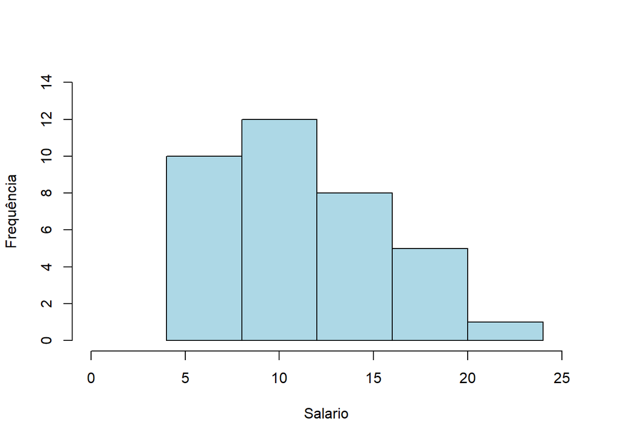

```r
hist(df$salario,breaks=seq(4,24,4),freq=TRUE,right=FALSE,
     xlim=c(0,25),ylim=c(0,14),col="lightblue",
     xlab="Salario",ylab="Frequência",main="")
```

```r
dev.off()
## null device
##           1
```

Alternativamente, é possível também construir o histograma densidade para a variável **salário**. No histograma densidade, a altura de cada barra é definida de tal forma que a área da barra é igual à frequência percentual da classe que ela representa. Assim, a soma das áreas de todas as barras do histograma é igual a 1. Em outras palavras, a área total do histograma é padronizada para 1 (ou 100%).

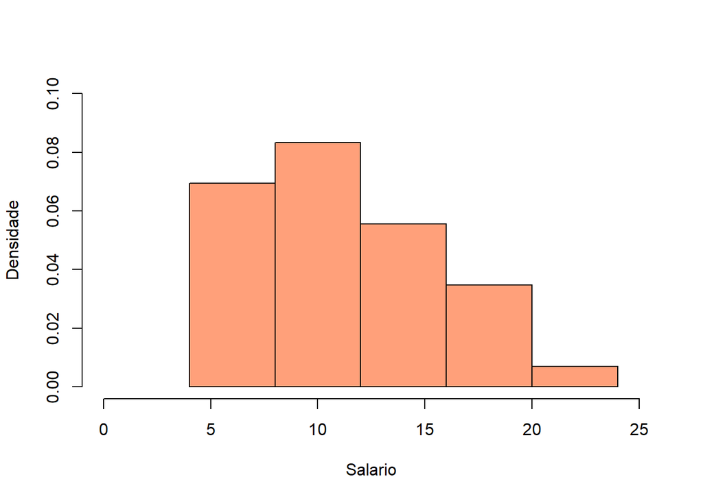

```r
hist(df$salario,breaks=seq(4,24,4),freq=FALSE,right=FALSE,
     xlim=c(0,25),ylim=c(0,0.10),col="lightsalmon",
     xlab="Salario",ylab="Densidade",main="")
```

```r
dev.off()
## null device
##           1
```

## 4.2 Gráfico de barras

Considere novamente a variável **número de filhos**, resumida na seguinte tabela de frequências.

| Número de filhos | Frequência | Frequência (%) |
| --- | --- | --- |
| 0 | 4 | 20 |
| 1 | 5 | 25 |
| 2 | 7 | 35 |
| 3 | 3 | 15 |
| 5 | 1 | 5 |
| Total | 20 | 100 |

A função `barplot()` pode ser usada para construir o gráfico de barras para a variável **número de filhos**.

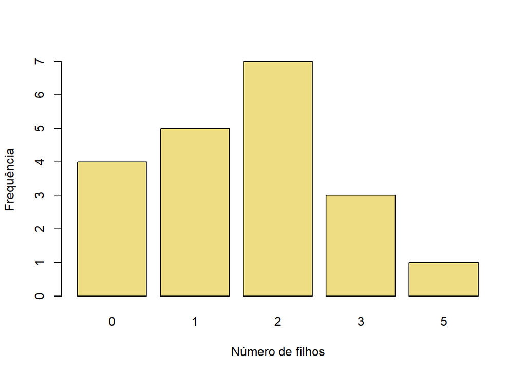

```r
barplot(table(df$n_filhos),col="lightgoldenrod",main="",xlab="Número de filhos",ylab="Frequência")
```

```r
dev.off()
## null device
##           1
```

## 4.3 Gráfico de setores

Considere novamente a variável **grau de instrução**, resumida na seguinte tabela de frequências.

| Grau de instrução | Frequência | Frequência (%) |
| --- | --- | --- |
| fundamental | 12 | 33.33 |
| medio | 18 | 50.00 |
| superior | 6 | 16.67 |
| Total | 36 | 100.00 |

A função `pie()` pode ser usada para construir o gráfico de setores para a variável **grau de instrução**.

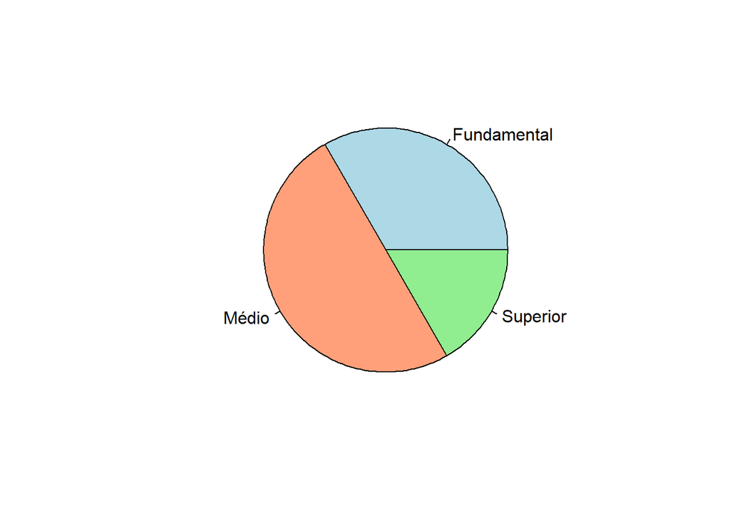

```r
rotulos <- c("Fundamental","Médio","Superior")
cores <- c("lightblue","lightsalmon","lightgreen")
pie(table(df$grau_instrucao),labels=rotulos,col=cores)
```

```r
dev.off()
## null device
##           1
```

## 4.4 Box-plot

Por fim, considere uma vez mais a variável **salário**. A função `boxplot()` pode ser usada para construir o gráfico box-plot para a variável **salário**.

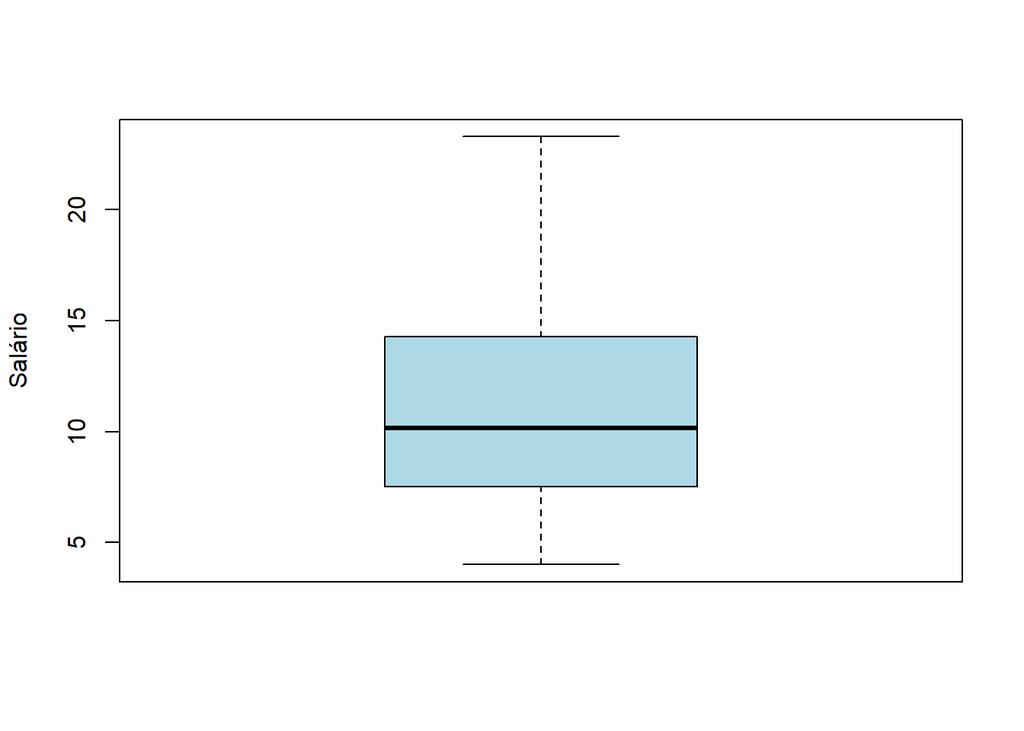

```r
summary(df$salario)
##    Min. 1st Qu.  Median    Mean 3rd Qu.    Max.
##   4.000   7.553  10.165  11.122  14.060  23.300
limite.superior <- min(max(df$salario),quantile(df$salario,0.75)+1.5*IQR(df$salario))
limite.inferior <- max(min(df$salario),quantile(df$salario,0.25)-1.5*IQR(df$salario))
c(limite.inferior,limite.superior)
## [1]  4.0 23.3
boxplot(df$salario,ylab="Salário",col="lightblue")
```

```r
dev.off()
## null device
##           1
```

# 5 Análise bivariada: variáveis categóricas

Nesta seção iremos considerar o seguinte conjunto de dados bivariado, extraído do Capítulo 4 da referência Morettin & Bussab (2010). Estamos interessados em verificar se a criação de determinado tipo de cooperativa está associado com o fator regional.

```r
niveis.e <- c("SP","PR","RS")
niveis.c <- c("consumidor","produtor","escola","outras")
cooperativa.sp <- rep(niveis.c,c(214,237,78,119))
cooperativa.pr <- rep(niveis.c,c(51,102,126,22))
cooperativa.rs <- rep(niveis.c,c(111,304,139,48))
estado <- factor(rep(niveis.e,c(648,301,602)),levels=niveis.e)
cooperativa <- factor(c(cooperativa.sp,cooperativa.pr,cooperativa.rs),levels=niveis.c)
df1 <- data.frame(Estado=estado,Tipo.cooperativa=cooperativa)
str(df1)
## 'data.frame':    1551 obs. of  2 variables:
##  $ Estado          : Factor w/ 3 levels "SP","PR","RS": 1 1 1 1 1 1 1 1 1 1 ...
##  $ Tipo.cooperativa: Factor w/ 4 levels "consumidor","produtor",..: 1 1 1 1 1 1 1 1 1 1 ...
head(df1)
##   Estado Tipo.cooperativa
## 1     SP       consumidor
## 2     SP       consumidor
## 3     SP       consumidor
## 4     SP       consumidor
## 5     SP       consumidor
## 6     SP       consumidor
tail(df1)
##      Estado Tipo.cooperativa
## 1546     RS           outras
## 1547     RS           outras
## 1548     RS           outras
## 1549     RS           outras
## 1550     RS           outras
## 1551     RS           outras
dim(df1)
## [1] 1551    2
```

## 5.1 Tabela de frequências (absolutas)

Considerando o conjunto de dados desta seção. Uma tabela de frequências de dupla entrada (ou tabela de contingência) para as variáveis **estado** e **tipo de cooperativa** pode ser construída aplicando as seguintes funções: `table()`e `addmargins()`.

```r
tf <- table(df1[,1],df1[,2])
tf
##
##      consumidor produtor escola outras
##   SP        214      237     78    119
##   PR         51      102    126     22
##   RS        111      304    139     48
rownames(tf)
## [1] "SP" "PR" "RS"
colnames(tf)
## [1] "consumidor" "produtor"   "escola"     "outras"
margin.table(tf,1)
##
##  SP  PR  RS
## 648 301 602
margin.table(tf,2)
##
## consumidor   produtor     escola     outras
##        376        643        343        189
tf1 <- addmargins(tf)
tf1
##
##       consumidor produtor escola outras  Sum
##   SP         214      237     78    119  648
##   PR          51      102    126     22  301
##   RS         111      304    139     48  602
##   Sum        376      643    343    189 1551
is.matrix(tf) # confirma que a estrutura de dados de tf é uma matriz
## [1] TRUE
is.matrix(tf1) # confirma que a estrutura de dados de tf1 é uma matriz
## [1] TRUE
```

Alternativamente, podemos obter o mesmo resultado aplicando as seguintes funções: `apply()`, `rbind()` e `cbind()`.

```r
apply(tf,1,sum)
##  SP  PR  RS
## 648 301 602
apply(tf,2,sum)
## consumidor   produtor     escola     outras
##        376        643        343        189
tf2 <- rbind(cbind(tf,apply(tf,1,sum)),apply(cbind(tf,apply(tf,1,sum)),2,sum))
rownames(tf2) <- c(rownames(tf),"total")
colnames(tf2) <- c(colnames(tf),"total")
tf2
##       consumidor produtor escola outras total
## SP           214      237     78    119   648
## PR            51      102    126     22   301
## RS           111      304    139     48   602
## total        376      643    343    189  1551
is.matrix(tf2)
## [1] TRUE
```

|  | consumidor | produtor | escola | outras | total |
| --- | --- | --- | --- | --- | --- |
| SP | 214 | 237 | 78 | 119 | 648 |
| PR | 51 | 102 | 126 | 22 | 301 |
| RS | 111 | 304 | 139 | 48 | 602 |
| total | 376 | 643 | 343 | 189 | 1551 |

## 5.2 Tabela de frequências relativas

Uma tabela de frequências relativas de dupla entrada para as variáveis **estado** e **tipo de cooperativa** pode ser construída com um dos seguintes scripts.

```r
#
# Script 1
#
tf.p <- (tf/sum(tf))
tf3 <- (tf.p)*100
tf3 <- addmargins(tf3)
rownames(tf3) <- c(rownames(tf),"total")
colnames(tf3) <- c(colnames(tf),"total")
round(tf3,1)
##
##         consumidor produtor escola outras total
##   SP          13.8     15.3    5.0    7.7  41.8
##   PR           3.3      6.6    8.1    1.4  19.4
##   RS           7.2     19.6    9.0    3.1  38.8
##   total       24.2     41.5   22.1   12.2 100.0
#
# Alternativamente, script 2
#
tf4 <- (tf.p)*100
tf4 <- rbind(cbind(tf4,apply(tf4,1,sum)),apply(cbind(tf4,apply(tf4,1,sum)),2,sum))
rownames(tf4) <- c(rownames(tf),"total")
colnames(tf4) <- c(colnames(tf),"total")
round(tf4,1)
##       consumidor produtor escola outras total
## SP          13.8     15.3    5.0    7.7  41.8
## PR           3.3      6.6    8.1    1.4  19.4
## RS           7.2     19.6    9.0    3.1  38.8
## total       24.2     41.5   22.1   12.2 100.0
```

## 5.3 Tabela de frequências relativas condicionais

Uma tabela de frequências relativas condicionais de dupla entrada para as variáveis **estado** e **tipo de cooperativa** pode ser construída utilizando a função `prop.table()`. O segundo argumento desta função indica se frequências relativas condicionais devem ser calculadas em relação aos totais marginais das linhas (se `margin=1`) ou se frequências relativas condicionais devem ser calculadas em relação aos totais marginais das colunas (se `margin=2`).

```r
tf5 <- prop.table(tf,margin=1)
round(tf5*100,1)
##
##      consumidor produtor escola outras
##   SP       33.0     36.6   12.0   18.4
##   PR       16.9     33.9   41.9    7.3
##   RS       18.4     50.5   23.1    8.0
tf5 <- rbind(tf5,margin.table(tf,2)/sum(tf))
tf5 <- cbind(tf5,margin.table(tf5,1))
rownames(tf5) <- c(rownames(tf),"total")
colnames(tf5) <- c(colnames(tf),"total")
round(tf5*100,1)
##       consumidor produtor escola outras total
## SP          33.0     36.6   12.0   18.4   100
## PR          16.9     33.9   41.9    7.3   100
## RS          18.4     50.5   23.1    8.0   100
## total       24.2     41.5   22.1   12.2   100
```

## 5.4 Gráfico de barras

A função `barplot()` também pode ser usada para construir gráficos de barras a partir de tabelas de frequências de dupla entrada, quer sejam frequências absolutas, relativas ou relativas condicionais. Como exemplo, considere o conjunto de dados bivariado desta seção envolvendo as variáveis **estado** e **tipo de cooperativa**.

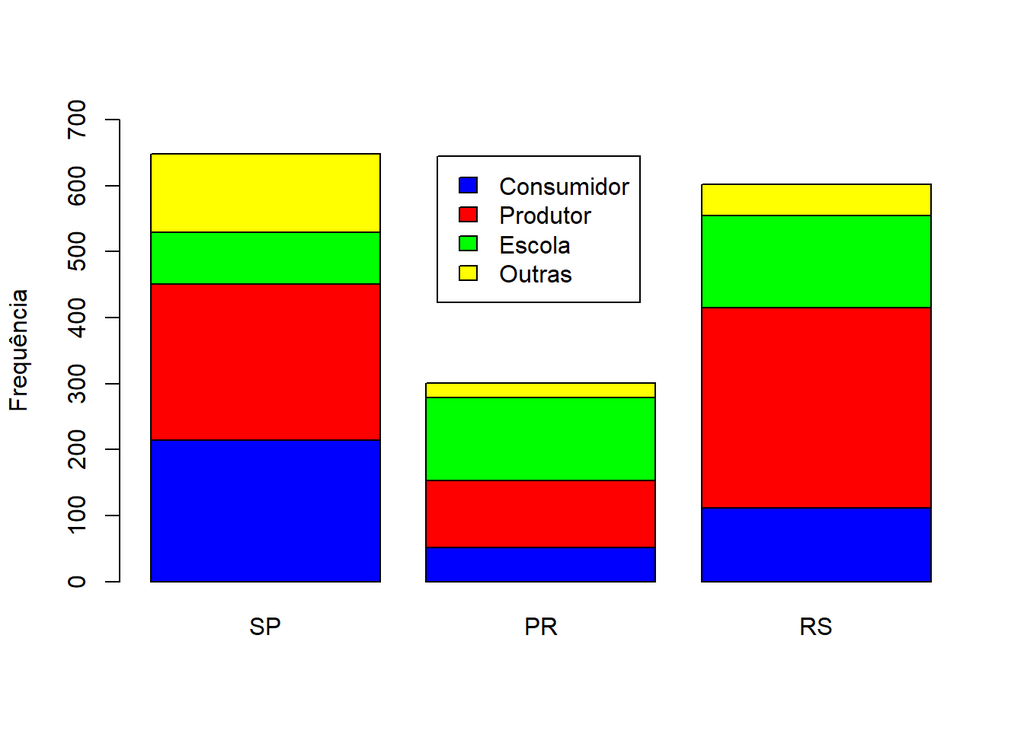

```r
tf
##
##      consumidor produtor escola outras
##   SP        214      237     78    119
##   PR         51      102    126     22
##   RS        111      304    139     48
t(tf)
##
##               SP  PR  RS
##   consumidor 214  51 111
##   produtor   237 102 304
##   escola      78 126 139
##   outras     119  22  48
cores <- c("blue","red","green","yellow")
legenda <- c("Consumidor","Produtor","Escola","Outras")
barplot(t(tf),col=cores,ylab="Frequência",ylim=c(0,700))
legend(1.45,645,legend=legenda,fill=cores)
```

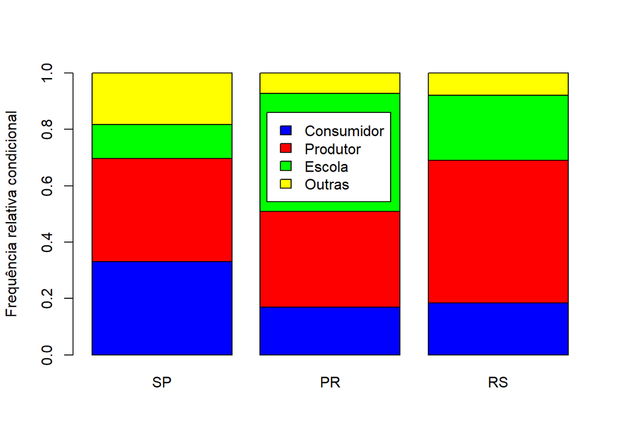

```r
round(100*prop.table(tf,1),1)
##
##      consumidor produtor escola outras
##   SP       33.0     36.6   12.0   18.4
##   PR       16.9     33.9   41.9    7.3
##   RS       18.4     50.5   23.1    8.0
round(100*t(prop.table(tf,1)),1)
##
##                SP   PR   RS
##   consumidor 33.0 16.9 18.4
##   produtor   36.6 33.9 50.5
##   escola     12.0 41.9 23.1
##   outras     18.4  7.3  8.0
cores <- c("blue","red","green","yellow")
legenda <- c("Consumidor","Produtor","Escola","Outras")
barplot(t(prop.table(tf,1)),col=cores,ylab="Frequência relativa condicional",ylim=c(0,1))
legend(1.45,0.86,legend=legenda,fill=cores)
```

```r
dev.off()
## null device
##           1
```

## 5.5 Associação entre variáveis categóricas

A função `chisq.test()` pode ser utilizada para realiza o seguinte teste de hipóteses envolvendo duas variáveis categóricas:
$$\begin{cases}
H_{0}: & \mbox{$X$ e $Y$ são independentes} \\
H_{1}: & \mbox{$X$ e $Y$ não são independentes} \\
& \mbox{($X$ e $Y$ estão associadas)}
\end{cases}$$
Como exemplo, considere o conjunto de dados bivariado desta seção envolvendo as variáveis **estado** e **tipo de cooperativa**. Se $X$ representa **estado** e $Y$ representa **tipo de cooperativa**, podemos usar a função `chisq.test()` para testar se **estado** e **tipo de cooperativa** são variáveis independentes. O resultado deste teste mostra que não existem evidências nos dados que suportam a hipótese nula $H_{0}$ de independência entre as variáveis (observe que o `p-value` do teste é muito pequeno). Isto significa que existe associação (ou dependência) entre as variáveis **estado** e **tipo de cooperativa**. Em outras palavras, existem evidências nos dados que o **tipo de cooperativa** depende do **estado** (ou seja, da localização).

```r
tf
##
##      consumidor produtor escola outras
##   SP        214      237     78    119
##   PR         51      102    126     22
##   RS        111      304    139     48
round(100*prop.table(tf,1),1)
##
##      consumidor produtor escola outras
##   SP       33.0     36.6   12.0   18.4
##   PR       16.9     33.9   41.9    7.3
##   RS       18.4     50.5   23.1    8.0
round(100*prop.table(tf,2),1)
##
##      consumidor produtor escola outras
##   SP       56.9     36.9   22.7   63.0
##   PR       13.6     15.9   36.7   11.6
##   RS       29.5     47.3   40.5   25.4
chisq.test(tf)
##
##  Pearson's Chi-squared test
##
## data:  tf
## X-squared = 173.38, df = 6, p-value < 2.2e-16
```

O resultado que o **tipo de cooperativa** depende do **estado** está em concordância com a análise gráfica. Se **estado** e **tipo de cooperativa** fossem variáveis independentes, a distribuição de frequências relativas do **tipo de cooperativa** condicionada ao **estado** não iria variar significativamente com a localidade. O que observamos no seguinte gráfico é exatamente o contrário. De fato, o gráfico mostra que a distribuição de frequências relativas do **tipo de cooperativa** condicionada ao **estado** varia significativamente com a localidade.

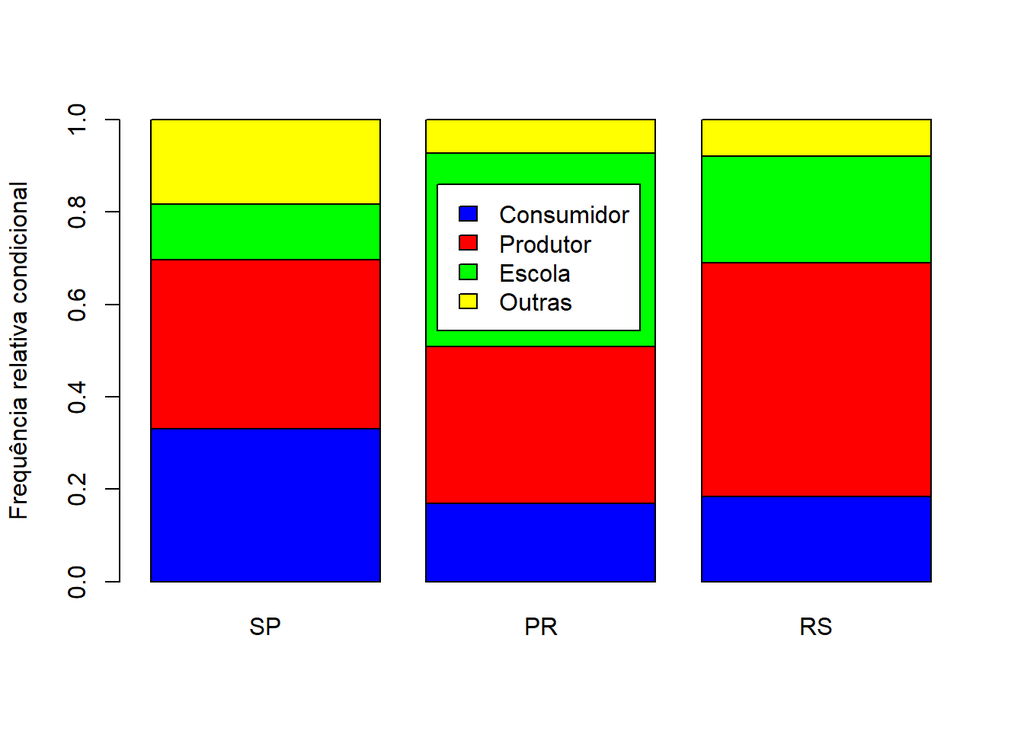

# 6 Análise bivariada: variáveis numéricas

Nesta seção conside o seguinte conjunto de dados bivariado, extraído do Capítulo 4 da referência Morettin & Bussab (2010). A variável $x$ representa a renda bruta familiar mensal e a variável $y$ representa a porcentagem da renda bruta familiar mensal que é gasta com saúde. Estamos interessados em verificar se a variável $y$ pode ser explicada em função da variável $x$ através de um modelo linear definido por:
$$\hat{y}=\hat{a}+\hat{b}x$$
onde $\hat{a}$ e $\hat{b}$ são os parâmetros estimados do modelo (estimados a partir dos dados) e $\hat{y}$ é o valor predito para a porcentagem da renda bruta familiar mensal que é gasta com saúde para um dado valor $x$ da renda bruta familiar mensal. Os dados são:

```r
# x: renda bruta familiar mensal
x <- c(12,16,18,20,28,30,40,48,50,54)
# y: porcentagem da renda bruta familiar mensal gasta com saúde
y <- c(7.2,7.4,7.0,6.5,6.6,6.7,6.0,5.6,6.0,5.5)
f <- LETTERS[1:10]
df2a <- data.frame(Familia=f,x,y)
df2a
##    Familia  x   y
## 1        A 12 7.2
## 2        B 16 7.4
## 3        C 18 7.0
## 4        D 20 6.5
## 5        E 28 6.6
## 6        F 30 6.7
## 7        G 40 6.0
## 8        H 48 5.6
## 9        I 50 6.0
## 10       J 54 5.5
is.data.frame(df2a)
## [1] TRUE
str(df2a)
## 'data.frame':    10 obs. of  3 variables:
##  $ Familia: chr  "A" "B" "C" "D" ...
##  $ x      : num  12 16 18 20 28 30 40 48 50 54
##  $ y      : num  7.2 7.4 7 6.5 6.6 6.7 6 5.6 6 5.5
```

| Familia | x | y |
| --- | --- | --- |
| A | 12 | 7.2 |
| B | 16 | 7.4 |
| C | 18 | 7.0 |
| D | 20 | 6.5 |
| E | 28 | 6.6 |
| F | 30 | 6.7 |
| G | 40 | 6.0 |
| H | 48 | 5.6 |
| I | 50 | 6.0 |
| J | 54 | 5.5 |

## 6.1 Gráfico de dispersão

Considere o conjunto de dados desta seção. Podemos visualizar este conjunto de dados através de um gráfico chamado de gráfico de dispersão. Este gráfico pode ser construído utilizando a função `plot()` conforme o script que segue.

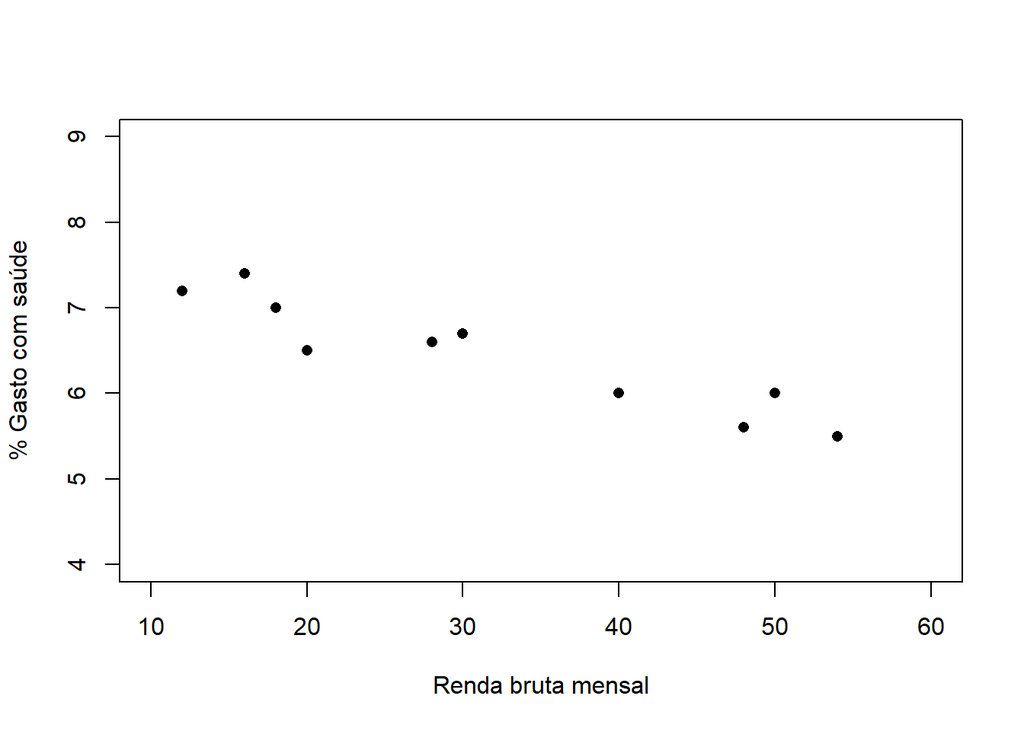

```r
#
# Para construir o gráfico de dispersão não
# necessitaremos da coluna Familia. Sendo
# assim, vamos considerar apenas as colunas
# correspondentes às variáveis x e y.
#
df2 <- df2a[,-1]
df2
##     x   y
## 1  12 7.2
## 2  16 7.4
## 3  18 7.0
## 4  20 6.5
## 5  28 6.6
## 6  30 6.7
## 7  40 6.0
## 8  48 5.6
## 9  50 6.0
## 10 54 5.5
plot(df2$x,df2$y,type="p",xlim=c(10,60),ylim=c(4,9),xlab="Renda bruta mensal",ylab="% Gasto com saúde",pch=16)
```

```r
dev.off()
## null device
##           1
```

## 6.2 Associação linear entre variáveis numéricas

O conjunto de dados desta seção pode ser visto como duas amostras pareadas das variáveis $x$ e $y$, onde cada observação $x_{i}$ na primeira amostra está pareada com uma observação $y_{i}$ da segunda amostra, formando assim um par $(x_{i},y_{i})$ das variáveis $x$ e $y$, observado numa unidade experimental que, neste caso, é uma família. Após o gráfico de dispersão dos dados, outro passo importante que deve ser feito no estudo que desejamos realizar nesta seção e verificar se existe associação linear entre as variáveis $x$ e $y$. Como $x$ e $y$ são ambas variáveis numéricas, isto pode ser feito calculando o coeficiente de correlação amostral (de Pearson) definido por
$$r=\frac{\sum_{i}(x_{i}-\bar{x})(y_{i}-\bar{y})}
{\sqrt{\sum_{i}(x_{i}-\bar{x})^{2}\cdot\sum_{i}(y_{i}-\bar{y})^{2}}}$$
que é um estimador do coeficiente de correlação populacional entre $x$ e $y$, definido por
$$\rho=\rho(x,y)=\frac{Cov(x,y)}{\sigma_{x}\cdot\sigma_{y}}$$
e geralmente desconhecido. Além disso, o seguinte teste de hipóteses deve ser realizado:
$$\begin{cases}
H_{0}: & \rho=0\hspace{0.5cm}(\mbox{Não existe correlação entre $x$
e $y$})\\
H_{1}: & \rho\not=0 \hspace{0.5cm}(\mbox{Existe correlação entre $x$
e $y$}).
\end{cases}$$
O seguinte script porporciona funções para calcular $r$ (a função `cor()`) e testar $H_{0}:\rho=0$ (a função `cor.test()`).

```r
summary(df2)
##        x              y
##  Min.   :12.0   Min.   :5.500
##  1st Qu.:18.5   1st Qu.:6.000
##  Median :29.0   Median :6.550
##  Mean   :31.6   Mean   :6.450
##  3rd Qu.:46.0   3rd Qu.:6.925
##  Max.   :54.0   Max.   :7.400
c(var(df2$x),var(df2$y))
## [1] 238.0444444   0.4316667
c(sd(df2$x),sd(df2$y))
## [1] 15.4286890  0.6570134
cov(df2$x,df2$y)
## [1] -9.533333
cor(df2$x,df2$y)
## [1] -0.9404625
cov(df2)
##            x          y
## x 238.044444 -9.5333333
## y  -9.533333  0.4316667
cor(df2,method="pearson")
##            x          y
## x  1.0000000 -0.9404625
## y -0.9404625  1.0000000
cor.test(df2$x,df2$y,method="pearson")
##
##  Pearson's product-moment correlation
##
## data:  df2$x and df2$y
## t = -7.826, df = 8, p-value = 5.114e-05
## alternative hypothesis: true correlation is not equal to 0
## 95 percent confidence interval:
##  -0.9861500 -0.7621149
## sample estimates:
##        cor
## -0.9404625
```

Os resultados mostram que $r=\hat{\rho}=-0.9404625$. Ou seja, a variável **renda bruta familiar mensal** é fortemente correlacionada como a variável **porcentagem da renda bruta familiar mensal gasta com saúde** e esta correlação é negativa, que significa que quanto maior for a renda bruta menor será a porcentagem da renda bruta gasta com saúde e vice-versa. Além disso, o resultado do teste mostra que não existem evidências nos dados que suportam a hipótese $H_{0}$ de correlação nula (independência entre as variáveis supondo normalidade). Observe que o `p-value` do teste é muito pequeno. Isto significa que a correlação linear (ou associação linear ou dependência linear) entre as variáveis **renda bruta familiar mensal** e **porcentagem da renda bruta familiar mensal gasta com saúde** é estatisticamente significativa.

## 6.3 Estimação da reta de mínimos quadrados

Como existe uma correlação estatisticamente significativa entre as variáveis **renda bruta familiar mensal** (representada por $x$) e **porcentagem da renda bruta familiar mensal gasta com saúde** (representada por $y$), estamos agora interessados em construir o modelo linear definido por:
$$\hat{y}=\hat{a}+\hat{b}x$$
onde $\hat{a}$ e $\hat{b}$ são parâmetros estimados do modelo e $\hat{y}$ é o valor predito para a porcentagem da renda bruta familiar mensal que é gasta com saúde para um dado valor $x$ da renda bruta familiar mensal. Podemos usar a função `lm()` para desenvolver este modelo, conforme o seguinte script.

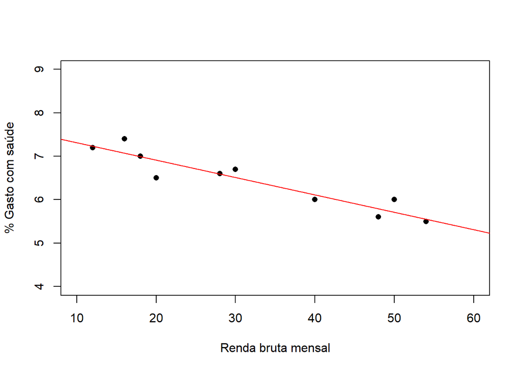

```r
modelo <- lm(y~x,data=df2)
summary(modelo)
##
## Call:
## lm(formula = y ~ x, data = df2)
##
## Residuals:
##      Min       1Q   Median       3Q      Max
## -0.41456 -0.09842 -0.01481  0.14090  0.32524
##
## Coefficients:
##              Estimate Std. Error t value Pr(>|t|)
## (Intercept)  7.715534   0.178214  43.294 8.94e-11 ***
## x           -0.040049   0.005117  -7.826 5.11e-05 ***
## ---
## Signif. codes:  0 '***' 0.001 '**' 0.01 '*' 0.05 '.' 0.1 ' ' 1
##
## Residual standard error: 0.2369 on 8 degrees of freedom
## Multiple R-squared:  0.8845, Adjusted R-squared:   0.87
## F-statistic: 61.25 on 1 and 8 DF,  p-value: 5.114e-05
anova(modelo)
## Analysis of Variance Table
##
## Response: y
##           Df Sum Sq Mean Sq F value    Pr(>F)
## x          1 3.4362  3.4362  61.246 5.114e-05 ***
## Residuals  8 0.4488  0.0561
## ---
## Signif. codes:  0 '***' 0.001 '**' 0.01 '*' 0.05 '.' 0.1 ' ' 1
plot(df2,type="p",xlim=c(10,60),ylim=c(4,9),xlab="Renda bruta mensal",ylab="% Gasto com saúde",pch=16)
abline(modelo,col="red")
```

```r
dev.off()
## null device
##           1
```

Os resultados mostram que o modelo estimado é dado por:
$$\hat{y}=7.715534-0.040049x.$$
Este modelo está representado pela linha vermelha no gráfico acima e pode ser aplicado para proporcionar um valor predito para a porcentagem da renda bruta familiar mensal que é gasta com saúde para um dado valor $x$ da renda bruta familiar mensal inicialmente não observada nos dados. Por exemplo, digamos que queremos prever a porcentagem da renda bruta familiar mensal que é gasta com saúde para o valor $x=33$ de renda bruta familiar mensal. Manualmente, basta fazer a seguinte conta:
$$\hat{y}=7.715534-0.040049(33)=6.393917.$$
Alternativamente, esta predição pode ser feita automática utilizando a função `predict()`.

```r
predict(modelo,data.frame(x=33))
##        1
## 6.393932
#
# Se desejar predições para diversos valores ao mesmo tempo
#
predict(modelo,data.frame(x=c(23,33,43)))
##        1        2        3
## 6.794417 6.393932 5.993447
#
# Note que também
#
names(modelo)
##  [1] "coefficients"  "residuals"     "effects"       "rank"
##  [5] "fitted.values" "assign"        "qr"            "df.residual"
##  [9] "xlevels"       "call"          "terms"         "model"
coefficients(modelo)
## (Intercept)           x
##  7.71553398 -0.04004854
x0 <- c(23,33,43)
y.hat <- coefficients(modelo)[1]+coefficients(modelo)[2]*x0
y.hat
## [1] 6.794417 6.393932 5.993447
```

# 7 Análise bivariada: categórica e numérica

Nesta seção considere novamente o conjunto de dados utilizado nas quatro primeiras seções deste material. Particularmente, aqui nesta seção, estamos interessados no conjunto de dados bivariado envolvendo as variáveis **grau de instrução** e **salário**. Este conjunto de dados contém, portanto, uma variável categórica e outra numérica. Os dados são:

```r
df3 <- subset(df,select=c("grau_instrucao","salario"))
colnames(df3) <- c("Grau_instrucao","Salario")
levels(df3$Grau_instrucao) <- c("Fundamental","Medio","Superior")
str(df3)
## 'data.frame':    36 obs. of  2 variables:
##  $ Grau_instrucao: Ord.factor w/ 3 levels "Fundamental"<..: 1 1 1 2 1 1 1 1 2 2 ...
##  $ Salario       : num  4 4.56 5.25 5.73 6.26 6.66 6.86 7.39 7.59 7.44 ...
head(df3)
##   Grau_instrucao Salario
## 1    Fundamental    4.00
## 2    Fundamental    4.56
## 3    Fundamental    5.25
## 4          Medio    5.73
## 5    Fundamental    6.26
## 6    Fundamental    6.66
```

Nossa análise se torna mais fácil se ordenarmos os dados conforme os níveis da variável **grau de instrução**.

```r
f <- which(df3$Grau_instrucao==levels(df3$Grau_instrucao)[1])
m <- which(df3$Grau_instrucao==levels(df3$Grau_instrucao)[2])
s <- which(df3$Grau_instrucao==levels(df3$Grau_instrucao)[3])
df3o <- df3[c(f,m,s),]
df3o
##    Grau_instrucao Salario
## 1     Fundamental    4.00
## 2     Fundamental    4.56
## 3     Fundamental    5.25
## 5     Fundamental    6.26
## 6     Fundamental    6.66
## 7     Fundamental    6.86
## 8     Fundamental    7.39
## 12    Fundamental    8.46
## 14    Fundamental    8.95
## 18    Fundamental    9.80
## 23    Fundamental   12.00
## 27    Fundamental   13.85
## 4           Medio    5.73
## 9           Medio    7.59
## 10          Medio    7.44
## 11          Medio    8.12
## 13          Medio    8.74
## 15          Medio    9.13
## 16          Medio    9.35
## 17          Medio    9.77
## 20          Medio   10.76
## 21          Medio   11.06
## 22          Medio   11.59
## 25          Medio   13.23
## 26          Medio   13.60
## 28          Medio   14.69
## 29          Medio   14.71
## 30          Medio   15.99
## 32          Medio   16.61
## 35          Medio   19.40
## 19       Superior   10.53
## 24       Superior   12.79
## 31       Superior   16.22
## 33       Superior   17.26
## 34       Superior   18.75
## 36       Superior   23.30
```

Podemos usar a função `boxplot()` para obter uma visualização gráfica deste conjunto de dados.

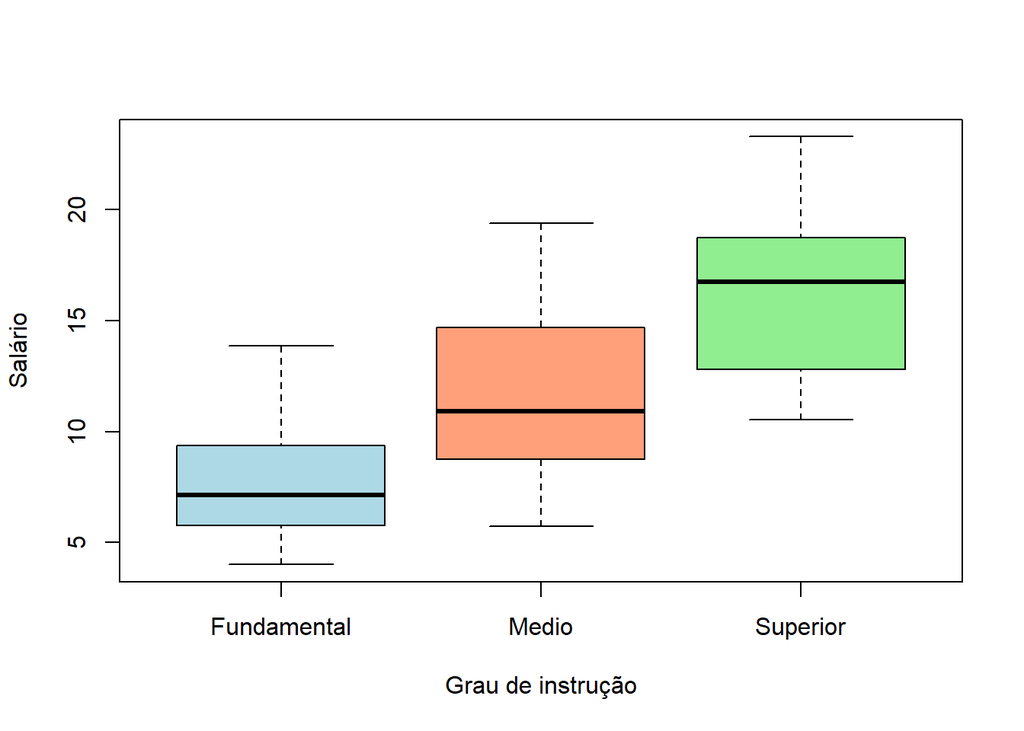

```r
boxplot(df3o$Salario~df3o$Grau_instrucao,
        xlab="Grau de instrução",ylab="Salário",
        col=c("lightblue","lightsalmon","lightgreen"))
```

Sintese numérica por ser obtida como segue:

```r
n <- as.vector(c(table(df3o$Grau_instrucao),sum(table(df3o$Grau_instrucao))))
todos <- as.vector(summary(df3o$Salario))
g.f <- summary(subset(df3o,subset=Grau_instrucao==levels(df3o$Grau_instrucao)[1])$Salario)
g.m <- summary(subset(df3o,subset=Grau_instrucao==levels(df3o$Grau_instrucao)[2])$Salario)
g.s <- summary(subset(df3o,subset=Grau_instrucao==levels(df3o$Grau_instrucao)[3])$Salario)
g.f <- as.vector(g.f);g.m <- as.vector(g.m);g.s <- as.vector(g.s)
dp.f <- sd(subset(df3o,subset=Grau_instrucao==levels(df3o$Grau_instrucao)[1])$Salario)
dp.m <- sd(subset(df3o,subset=Grau_instrucao==levels(df3o$Grau_instrucao)[2])$Salario)
dp.s <- sd(subset(df3o,subset=Grau_instrucao==levels(df3o$Grau_instrucao)[3])$Salario)
dp.t <- sd(df3o$Salario)
dp <- c(dp.f,dp.m,dp.s,dp.t);var <- dp^(2)
resumo <- data.frame(Fundamental=g.f,Médio=g.m,Superior=g.s,Todos=todos)
resumo <- rbind(n,resumo,var,dp)
rownames(resumo) <- c("n","Min","Q1","Mediana","Média","Q3","Máx","Variância","Desvio Padrão")
resumo
##               Fundamental     Médio  Superior     Todos
## n               12.000000 18.000000  6.000000 36.000000
## Min              4.000000  5.730000 10.530000  4.000000
## Q1               6.007500  8.837500 13.647500  7.552500
## Mediana          7.125000 10.910000 16.740000 10.165000
## Média            7.836667 11.528333 16.475000 11.122222
## Q3               9.162500 14.417500 18.377500 14.060000
## Máx             13.850000 19.400000 23.300000 23.300000
## Variância        8.740679 13.802297 20.271950 21.044766
## Desvio Padrão    2.956464  3.715144  4.502438  4.587458
```